# analyse_texte_Amazon

**Made By DAHOU RENAUD L. Data Scientist in Benin**

- Whatsapp: +22967927952
- Email: dahou.r@yahoo.com

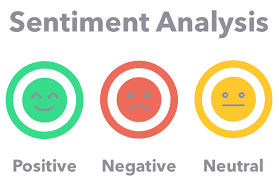

Nous savons que les avis sur les produits Amazon importent aux marchands, car ces avis ont un impact considérable sur la façon dont nous prenons les décisions d'achat. J'ai donc téléchargé un ensemble de données sur les revues gastronomiques Amazon de [Kaggle](https://www.kaggle.com/snap/amazon-fine-food-reviews), provenant à l' origine de SNAP , pour voir ce que je pourrais apprendre de cet ensemble de données volumineux.

### Connexion à notre répertoire

```python
from google.colab import drive
drive.mount('/content/drive/')
```

```python
import os
os.chdir("/content/drive/My Drive/DATASCIENCE/Projet/Analyse_sentiment ")
import warnings
warnings.simplefilter("ignore")
```

```python
#!jupyter nbconvert --to html analyse_texte_Amazon.ipynb
```

### Les données

En regardant l'en-tête du bloc de données, nous pouvons voir qu'il se compose des informations suivantes:

1. Product Id
2. User Id
3. ProfileName
4. HelpfulnessNumerator
5. HelpfulnessDenominator
6. Score
7. Time
8. Summary
9. Text

```python
import pandas as pd
import numpy as np
import matplotlib.pyplot as plt

from pprint import pprint
from time import time
import logging

from sklearn.feature_extraction.text import CountVectorizer
from sklearn.feature_extraction.text import TfidfTransformer
from sklearn.ensemble import RandomForestClassifier
from sklearn.svm import LinearSVC
from sklearn.naive_bayes import MultinomialNB
from sklearn.linear_model import LogisticRegression

from sklearn.model_selection import cross_val_score
from sklearn.model_selection import GridSearchCV
from sklearn.pipeline import Pipeline

from sklearn.model_selection import train_test_split
from sklearn.metrics import roc_auc_score
```

```python
df = pd.read_csv('Reviews.csv')
df.head()
```

|  | Id | ProductId | UserId | ProfileName | HelpfulnessNumerator | HelpfulnessDenominator | Score | Time | Summary | Text |
| --- | --- | --- | --- | --- | --- | --- | --- | --- | --- | --- |
| 0 | 1 | B001E4KFG0 | A3SGXH7AUHU8GW | delmartian | 1 | 1 | 5 | 1303862400 | Good Quality Dog Food | I have bought several of the Vitality canned d... |
| 1 | 2 | B00813GRG4 | A1D87F6ZCVE5NK | dll pa | 0 | 0 | 1 | 1346976000 | Not as Advertised | Product arrived labeled as Jumbo Salted Peanut... |
| 2 | 3 | B000LQOCH0 | ABXLMWJIXXAIN | Natalia Corres "Natalia Corres" | 1 | 1 | 4 | 1219017600 | "Delight" says it all | This is a confection that has been around a fe... |
| 3 | 4 | B000UA0QIQ | A395BORC6FGVXV | Karl | 3 | 3 | 2 | 1307923200 | Cough Medicine | If you are looking for the secret ingredient i... |
| 4 | 5 | B006K2ZZ7K | A1UQRSCLF8GW1T | Michael D. Bigham "M. Wassir" | 0 | 0 | 5 | 1350777600 | Great taffy | Great taffy at a great price. There was a wid... |

```python
print(df.describe())
```

```
                  Id  HelpfulnessNumerator  ...          Score          Time
count  568454.000000         568454.000000  ...  568454.000000  5.684540e+05
mean   284227.500000              1.743817  ...       4.183199  1.296257e+09
std    164098.679298              7.636513  ...       1.310436  4.804331e+07
min         1.000000              0.000000  ...       1.000000  9.393408e+08
25%    142114.250000              0.000000  ...       4.000000  1.271290e+09
50%    284227.500000              0.000000  ...       5.000000  1.311120e+09
75%    426340.750000              2.000000  ...       5.000000  1.332720e+09
max    568454.000000            866.000000  ...       5.000000  1.351210e+09

[8 rows x 5 columns]
```

```python
# échantillonnage du jeux
df=df[:50000]
```

```python
print(df.describe())
```

```
                 Id  HelpfulnessNumerator  ...         Score          Time
count  50000.000000          50000.000000  ...  50000.000000  5.000000e+04
mean   25000.500000              1.603360  ...      4.145840  1.295198e+09
std    14433.901067              5.620771  ...      1.325596  4.734622e+07
min        1.000000              0.000000  ...      1.000000  9.617184e+08
25%    12500.750000              0.000000  ...      4.000000  1.269648e+09
50%    25000.500000              0.000000  ...      5.000000  1.309133e+09
75%    37500.250000              2.000000  ...      5.000000  1.331078e+09
max    50000.000000            398.000000  ...      5.000000  1.351210e+09

[8 rows x 5 columns]
```

```python
df.head()
```

|  | Id | ProductId | UserId | ProfileName | HelpfulnessNumerator | HelpfulnessDenominator | Score | Time | Summary | Text |
| --- | --- | --- | --- | --- | --- | --- | --- | --- | --- | --- |
| 0 | 1 | B001E4KFG0 | A3SGXH7AUHU8GW | delmartian | 1 | 1 | 5 | 1303862400 | Good Quality Dog Food | I have bought several of the Vitality canned d... |
| 1 | 2 | B00813GRG4 | A1D87F6ZCVE5NK | dll pa | 0 | 0 | 1 | 1346976000 | Not as Advertised | Product arrived labeled as Jumbo Salted Peanut... |
| 2 | 3 | B000LQOCH0 | ABXLMWJIXXAIN | Natalia Corres "Natalia Corres" | 1 | 1 | 4 | 1219017600 | "Delight" says it all | This is a confection that has been around a fe... |
| 3 | 4 | B000UA0QIQ | A395BORC6FGVXV | Karl | 3 | 3 | 2 | 1307923200 | Cough Medicine | If you are looking for the secret ingredient i... |
| 4 | 5 | B006K2ZZ7K | A1UQRSCLF8GW1T | Michael D. Bigham "M. Wassir" | 0 | 0 | 5 | 1350777600 | Great taffy | Great taffy at a great price. There was a wid... |

Pour ce qui nous concerne aujourd'hui, nous allons nous concentrer sur les colonnes Score et Text.

Commençons par nettoyer le cadre de données en supprimant les lignes contenant des valeurs manquantes.

```python
df.dropna(inplace=True)
df[df['Score'] != 3]
df['Positivity'] = np.where(df['Score'] > 3, 1, 0)
df.head()
```

|  | Id | ProductId | UserId | ProfileName | HelpfulnessNumerator | HelpfulnessDenominator | Score | Time | Summary | Text | Positivity |
| --- | --- | --- | --- | --- | --- | --- | --- | --- | --- | --- | --- |
| 0 | 1 | B001E4KFG0 | A3SGXH7AUHU8GW | delmartian | 1 | 1 | 5 | 1303862400 | Good Quality Dog Food | I have bought several of the Vitality canned d... | 1 |
| 1 | 2 | B00813GRG4 | A1D87F6ZCVE5NK | dll pa | 0 | 0 | 1 | 1346976000 | Not as Advertised | Product arrived labeled as Jumbo Salted Peanut... | 0 |
| 2 | 3 | B000LQOCH0 | ABXLMWJIXXAIN | Natalia Corres "Natalia Corres" | 1 | 1 | 4 | 1219017600 | "Delight" says it all | This is a confection that has been around a fe... | 1 |
| 3 | 4 | B000UA0QIQ | A395BORC6FGVXV | Karl | 3 | 3 | 2 | 1307923200 | Cough Medicine | If you are looking for the secret ingredient i... | 0 |
| 4 | 5 | B006K2ZZ7K | A1UQRSCLF8GW1T | Michael D. Bigham "M. Wassir" | 0 | 0 | 5 | 1350777600 | Great taffy | Great taffy at a great price. There was a wid... | 1 |

J'ai décidé de ne faire que l'analyse des sentiments sur cet ensemble de données, j'ai donc supprimé les colonnes inutiles, en ne conservant que les sentiments et le texte.

Dans une prochaine étape, j'ai séparé les avis positifs et négatifs de l'ensemble de formation afin de visualiser facilement leurs mots contenus. Après cela, j'ai nettoyé le texte des hashtags, des mentions et des liens. Maintenant, ils sont prêts pour une visualisation WordCloud qui ne montre que les mots les plus emphatiques des avis positifs et négatifs.

```python
from wordcloud import WordCloud,STOPWORDS
import matplotlib.pyplot as plt

train=df[['Text','Positivity']]

train_pos = train[ train['Positivity'] == 1]
train_pos = train_pos['Text']
train_neg = train[ train['Positivity'] == 0]
train_neg = train_neg['Text']

def wordcloud_draw(data, color = 'black'):
    words = ' '.join(data)
    cleaned_word = " ".join([word for word in words.split()
                            if 'http' not in word
                                and not word.startswith('@')
                                and not word.startswith('#')
                                and word != 'RT'
                            ])
    wordcloud = WordCloud(stopwords=STOPWORDS,
                      background_color=color,
                      width=2500,
                      height=2000
                     ).generate(cleaned_word)
    plt.figure(1,figsize=(13, 13))
    plt.imshow(wordcloud)
    plt.axis('off')
```

```
Positive words
```

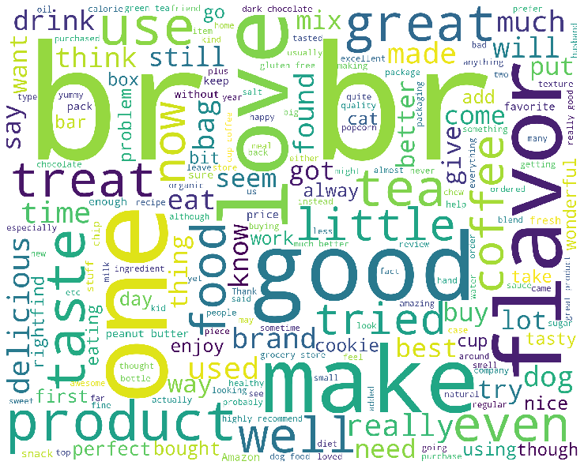

```python
print("Positive words")
wordcloud_draw(train_pos,'white')
```

```
Negative words
```

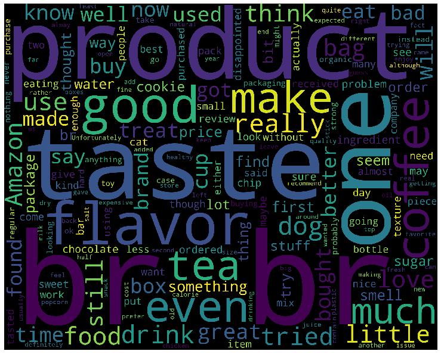

```python
print("Negative words")
wordcloud_draw(train_neg)
```

Intéressant de remarquer les mots et expressions suivants dans l'ensemble de mots positifs:good, love, délicious, product. Selon mon interprétation, les clients ont donné leur avis positif par rapport au gôut et au saveur d'un produit alimentaire

De l'ensemble negatif : coofee, tastes, tea, food,product, dog. selon mon interprétation, les clients ont donné plus leur avis neagatif par rapport au gôut et au saveur des produit telque le café

.

Après la visualisation, j'ai supprimé les hashtags, mentions, liens et stop words de l'ensemble de formation.

stop words: les stop words sont des mots qui n'ont pas de signification importante à utiliser dans les requêtes de recherche. Habituellement, ces mots sont exclus des requêtes de recherche car ils renvoient une grande quantité d'informations inutiles. ( the, for, this etc. ) dans notre cas

```python
pip install nltk
```

```python
import nltk
nltk.download("stopwords")
```

```
True
```

```python
import nltk
from nltk.corpus import stopwords


tweets = []
stopwords_set = set(stopwords.words("english"))

for index, row in train.iterrows():
    words_filtered = [e.lower() for e in row.Text.split() if len(e) >= 3]
    words_cleaned = [word for word in words_filtered
        if 'http' not in word
        and not word.startswith('@')
        and not word.startswith('#')
        and word != 'RT']
    words_without_stopwords = [word for word in words_cleaned if not word in stopwords_set]
    tweets.append((words_without_stopwords, row.Positivity))
```

Dans une étape suivante, j'ai extrait les soi-disant fonctionnalités avec nltk lib, d'abord en mesurant une distribution fréquente et en sélectionnant les clés résultantes.

```python
# Extracting word features
def get_words_in_tweets(tweets):
    all = []
    for (words, Positivity) in tweets:
        all.extend(words)
    return all

def get_word_features(wordlist):
    wordlist = nltk.FreqDist(wordlist)
    features = wordlist.keys()
    return features
w_features = get_word_features(get_words_in_tweets(tweets))

def extract_features(document):
    document_words = set(document)
    features = {}
    for word in w_features:
        features['contains(%s)' % word] = (word in document_words)
    return features
```

Par la présente, j'ai tracé les mots les plus fréquemment distribués. La plupart des avis clients sont centrés sur la saveur du café(coffee) , thé(tea) et du Chocolat

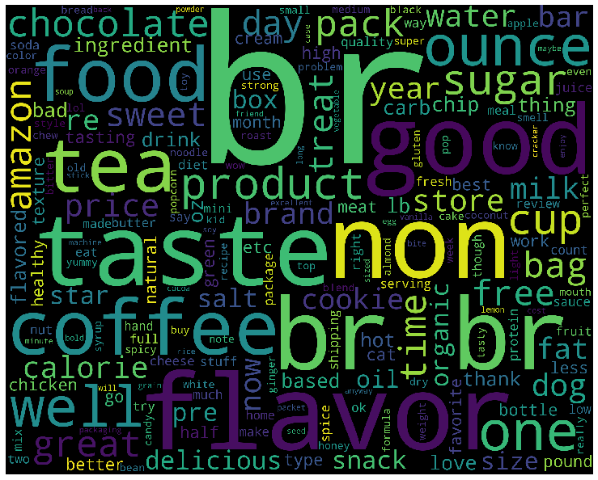

```python
wordcloud_draw(w_features)
```

Après avoir explorer nos text pour comprendre sur quoi porte en générale les avis des client nous allons passé à la classification des sentiement des clients

Ça à l'air bon.

Divisons maintenant nos données en sous-ensembles d'apprentissage et de test aléatoires à l'aide des colonnes «Texte» et «Positivité», puis imprimons la première entrée et la forme de l'ensemble d'apprentissage.

```python
X_train, X_test, y_train, y_test = train_test_split(df['Text'], df['Positivity'], random_state = 0)
print('X_train first entry: \n\n', X_train[0])
print('\n\nX_train shape: ', X_train.shape)
```

```
X_train first entry:

 I have bought several of the Vitality canned dog food products and have found them all to be of good quality. The product looks more like a stew than a processed meat and it smells better. My Labrador is finicky and she appreciates this product better than  most.


X_train shape:  (37496,)
```

### Bags-of-words

Le moyen le plus simple et le plus intuitif de le faire est la représentation de «Bags-of-words» qui ignore la structure et compte simplement la fréquence de chaque mot. CountVectorizer nous permet d’utiliser l’approche des Bags-of-words en convertissant une collection de documents texte en une matrice de comptes de token .

Nous instancions CountVectorizer et l’ajustons à nos données d’entraînement en convertissant notre collection de documents texte en une matrice de comptes de token .

### Pondération des termes Tf – idf

Dans un corpus de texte volumineux, certains mots seront présents très souvent, mais porteront très peu d’informations utiles sur le contenu réel du document (tels que «le», «un» et «est»). Si nous devions transmettre les données de comptage directement à un classificateur, ces termes très fréquents masqueraient les fréquences de termes plus rares et plus intéressants.

#### Tf-idf

nous permet de pondérer les termes en fonction de leur importance pour un document.

Nous allons donc instancier le tf–idf vectoriseur et l’adapter à nos données d’entraînement. si nous spécifions min_df = 5, ce qui supprimera tous les mots de notre vocabulaire qui apparaissent dans moins de cinq documents.

Nous sommes maintenant prêts à expérimenter différents modèles d’apprentissage automatique, à évaluer leur précision et à trouver la source de tout problème potentiel.

Nous allons comparer les quatre modèles suivants:

- Régression logistique
- (Multinomial) Naive Bayes
- Machine de vecteur de support linéaire
- Forêt aléatoire

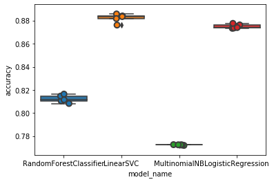

```python
vect = Pipeline([
    ('vect', CountVectorizer()),
    ('tfidf', TfidfTransformer()),
])


models = [
    RandomForestClassifier(),
    LinearSVC(),
    MultinomialNB(),
    LogisticRegression(),
]
CV = 5
cv_df = pd.DataFrame(index=range(CV * len(models)))
entries = []
for model in models:
  model_name = model.__class__.__name__
  accuracies = cross_val_score(model, vect.fit_transform(X_train), y_train, scoring='accuracy', cv=CV)
  for fold_idx, accuracy in enumerate(accuracies):
    entries.append((model_name, fold_idx, accuracy))
cv_df = pd.DataFrame(entries, columns=['model_name', 'fold_idx', 'accuracy'])
import seaborn as sns
sns.boxplot(x='model_name', y='accuracy', data=cv_df)
sns.stripplot(x='model_name', y='accuracy', data=cv_df,
              size=8, jitter=True, edgecolor="gray", linewidth=2)
plt.show()
```

```python
cv_df.groupby('model_name').accuracy.mean()
```

```
model_name
LinearSVC                 0.882201
LogisticRegression        0.874947
MultinomialNB             0.772402
RandomForestClassifier    0.812247
Name: accuracy, dtype: float64
```

LinearSVC fonctionnent mieux que les autres classificateurs, LinearSVC ayant un léger avantage avec un score moyen de 88%.

Nous allons rechercher les hyperparamètre qui optimise le mieux notre model

```python
# #############################################################################
# Define a pipeline combining a text feature extractor with a simple
# classifier
pipeline = Pipeline([
    ('vect', CountVectorizer()),
    ('tfidf', TfidfTransformer()),
    ('clf', LinearSVC()),
])

# uncommenting more parameters will give better exploring power but will
# increase processing time in a combinatorial way
parameters = {
    'vect__min_df': (5,10,15,20),
    'vect__max_features': (None, 5000, 10000, 50000),
    'vect__ngram_range': ((1, 1), (1, 2)),  # unigrams or bigrams
    'tfidf__use_idf': (True, False),
    'tfidf__norm': ('l1', 'l2'),
    #'clf__penalty': ('l1', 'l2'),
    #'clf__max_iter': (10, 50, 80),
}

if __name__ == "__main__":
    # multiprocessing requires the fork to happen in a __main__ protected
    # block

    # find the best parameters for both the feature extraction and the
    # classifier
    grid_search = GridSearchCV(pipeline, parameters, n_jobs=-1, verbose=1)

    print("Performing grid search...")
    print("pipeline:", [name for name, _ in pipeline.steps])
    print("parameters:")
    pprint(parameters)
    t0 = time()
    grid_search.fit(X_train, y_train)
    print("done in %0.3fs" % (time() - t0))
    print()

    print("Best score: %0.3f" % grid_search.best_score_)
    print("Best parameters set:")
    best_parameters = grid_search.best_estimator_.get_params()
    for param_name in sorted(parameters.keys()):
        print("\t%s: %r" % (param_name, best_parameters[param_name]))
```

```
Performing grid search...
pipeline: ['vect', 'tfidf', 'clf']
parameters:
{'tfidf__norm': ('l1', 'l2'),
 'tfidf__use_idf': (True, False),
 'vect__max_features': (None, 5000, 10000, 50000),
 'vect__min_df': (5, 10, 15, 20),
 'vect__ngram_range': ((1, 1), (1, 2))}
Fitting 5 folds for each of 128 candidates, totalling 640 fits
```

```
[Parallel(n_jobs=-1)]: Using backend LokyBackend with 4 concurrent workers.
[Parallel(n_jobs=-1)]: Done  42 tasks      | elapsed:  1.3min
[Parallel(n_jobs=-1)]: Done 192 tasks      | elapsed:  5.9min
[Parallel(n_jobs=-1)]: Done 442 tasks      | elapsed: 13.3min
[Parallel(n_jobs=-1)]: Done 640 out of 640 | elapsed: 19.1min finished
```

```
done in 1155.172s

Best score: 0.903
Best parameters set:
	tfidf__norm: 'l2'
	tfidf__use_idf: True
	vect__max_features: None
	vect__min_df: 5
	vect__ngram_range: (1, 2)
```

```python
print('Test Accuracy: %.3f' % grid_search.score(X_test, y_test))
y_pred = grid_search.predict(X_test)
print('AUC: ', roc_auc_score(y_test, y_pred))
```

```
Test Accuracy: 0.906
AUC:  0.8450359216092439
```

```python
vect=pipeline.named_steps['vect'].fit(X_train)
```

```python
import sklearn.metrics as metrics
print(metrics.confusion_matrix(y_test, y_pred))
```

```
[[2089  763]
 [ 409 9238]]
```

```python
# save confusion matrix and slice into four pieces
confusion = metrics.confusion_matrix(y_test, y_pred)
TP = confusion[1, 1]
TN = confusion[0, 0]
FP = confusion[0, 1]
FN = confusion[1, 0]
```

**pourcentage de Prediction correcte de notre modèle**

```python
print((TP + TN) / float(TP + TN + FP + FN))
print(metrics.accuracy_score(y_test, y_pred))
```

```
0.906232498599888
0.906232498599888
```

**pourcentage de Prediction incorrecte de notre modèle**

```python
print((FP + FN) / float(TP + TN + FP + FN))
print(1 - metrics.accuracy_score(y_test, y_pred))
```

```
0.093767501400112
0.09376750140011203
```

Sensibilité: lorsque la valeur réelle est positive, à quelle fréquence la prédiction est-elle correcte?

Dans quelle mesure le classificateur est-il "sensible" à la détection d'instances positives? Aussi connu comme "True Positive Rate" ou "Recall

```python
print(TP / float(TP + FN))
print(metrics.recall_score(y_test, y_pred))
```

```
0.9576034000207319
0.9576034000207319
```

Spécificité: lorsque la valeur réelle est négative, à quelle fréquence la prédiction est-elle correcte?

```python
print(TN / float(TN + FP))
```

```
0.732468443197756
```

**Faisons de nouvelle prediction**

```python
print(grid_search.predict((['The candy is not good, I will never buy them again','The candy is not bad, I will buy them again'])))
```

```
[0 1]
```

Notre model à trouver juste 0: avis negatif et 1 pour avis positif